# Тест #6

## Вариант #4

**Журавский Максим, группа 520**

```r
library("TSA")
library(aTSA)
library("tidyverse")
library(tseries)
library("lmtest")
library(rugarch)
```

### Исследование исходного временного ряда

Считаем файл с данными и отсортируем данные от старых к новым. Перейдем к дифференцированному ряду.

```r
df %>% head()
```

```
## # A tibble: 6 x 3
##   Date       Amount    Inc
##   <date>      <dbl>  <dbl>
## 1 2015-06-10  0.865 -2.91
## 2 2015-06-17  0.114 -0.751
## 3 2015-06-24  1.84   1.72
## 4 2015-07-01  0.392 -1.44
## 5 2015-07-08  1.64   1.25
## 6 2015-07-15  3.82   2.18
```

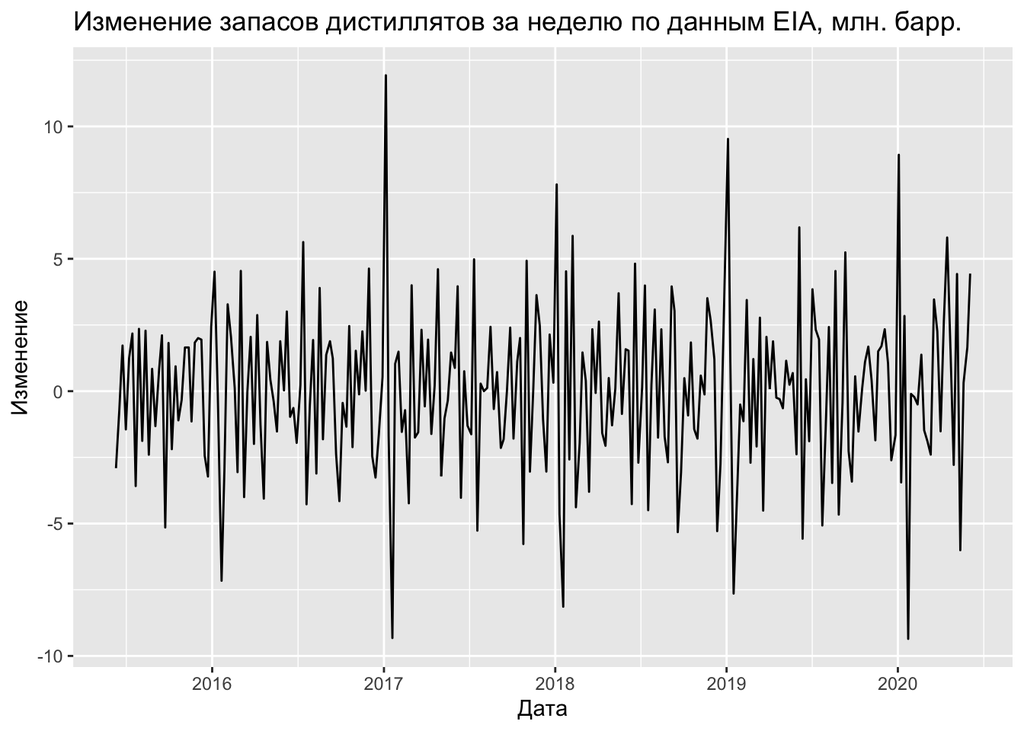

Для проверки гипотез будем использовать уровень значимости $\alpha = 0.05$.

```r
adf.test(df$Inc, k=60, alternative = c("stationary"))
```

```
##
##  Augmented Dickey-Fuller Test
##
## data:  df$Inc
## Dickey-Fuller = -1.564, Lag order = 60, p-value = 0.7595
## alternative hypothesis: stationary
```

Как упоминалось в прошлой работе, согласно графику и результату теста Дики-Фуллера мы не можем отвергать гипотезу о нестационарности временного ряда. В связи с этим рассмотрим сезонную разность $y_t = y_t - y_{t - 52}$.

```r
diff <- df %>%
  mutate(Diff = Inc - lag(Inc, n = 52)) %>%
  filter(!is.na(Diff))
```

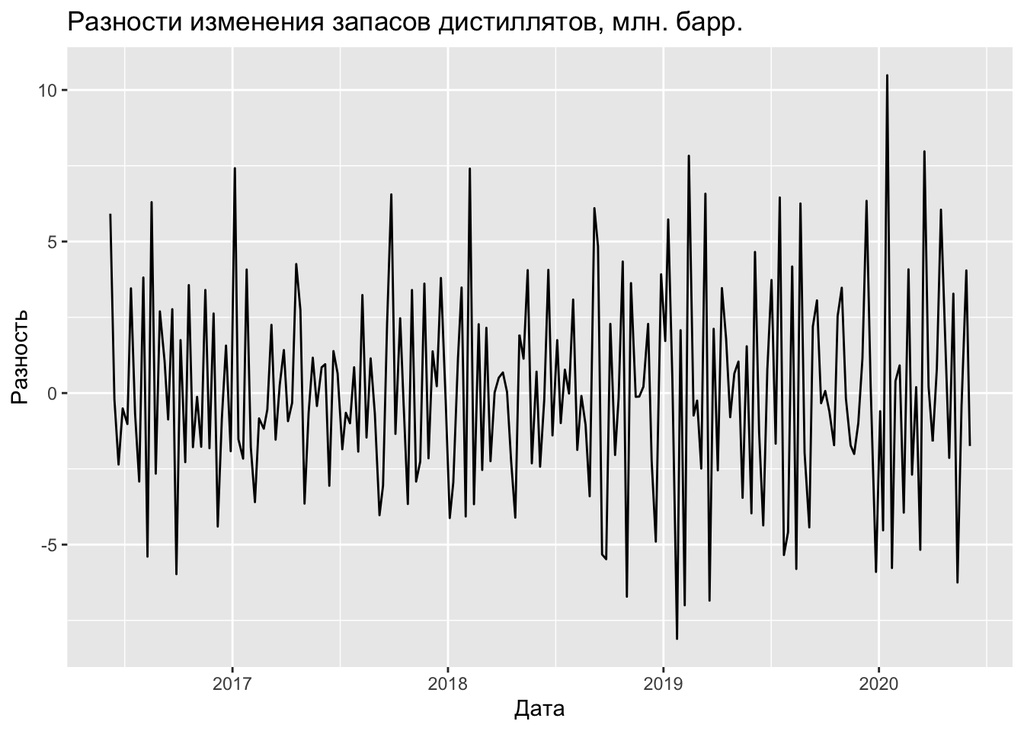

### ARMA модель

Исследуем ACF и PACF для исследуемого временного ряда.

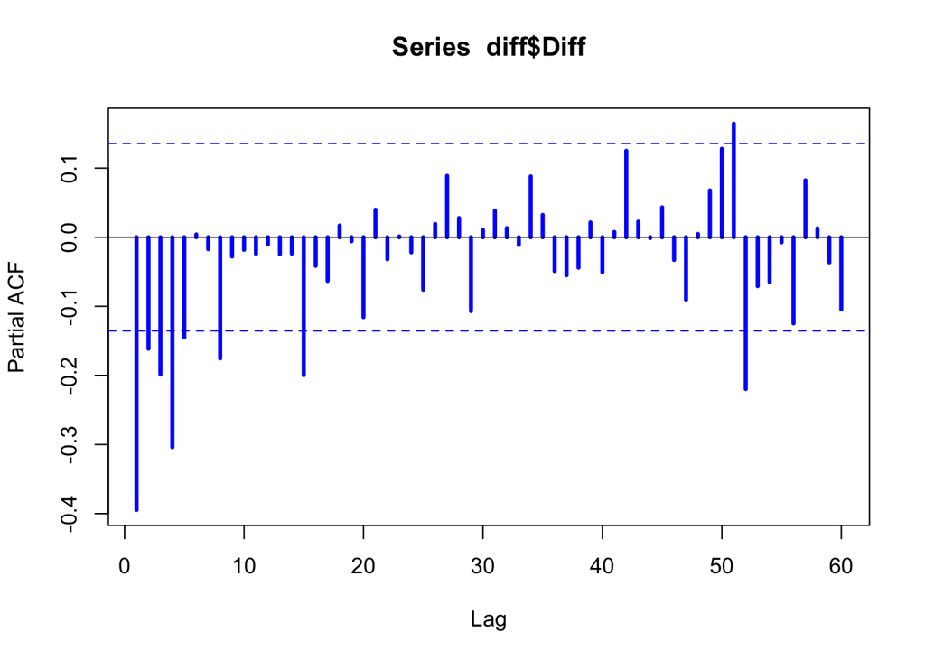

```r
pacf(diff$Diff, lwd = 3,lag.max = 60, col = "blue")
```

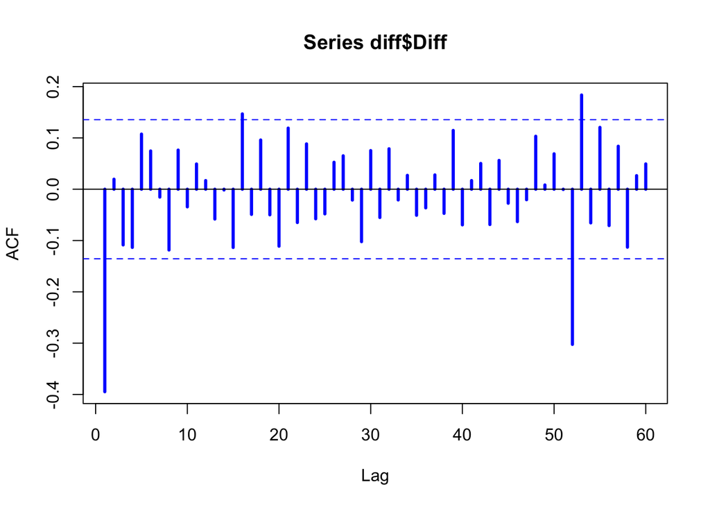

```r
acf(diff$Diff, lwd = 3,lag.max = 60, col = "blue")
```

По результатам предыдущей работы наилучшей ARMA моделью для исследуемого временного ряда является модель с сезонным скользящим средним первого порядка (период сезонности: 52 недели) и несезонным скользящим средним первого порядка. Для нее значение критерия Акаике равно 991.1562.

```r
ma_model <- arima(diff$Diff, order = c(0,0,1), seasonal = list(order=c(0,0,1), period=52),method = "ML")
print(ma_model$aic)
```

```
## [1] 991.1562
```

Проверим гипотезу о гомоскедестичности остатков с помощью теста Энгла.

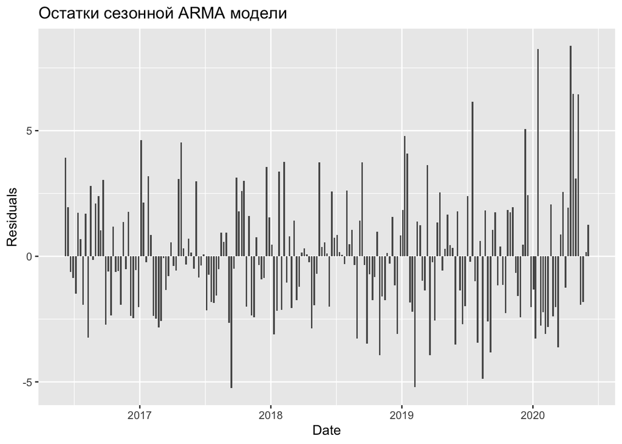

```r
residuals <- tibble(
  Date=diff$Date,
  Residuals=ma_model$residuals
)
ggplot(residuals, aes(x=Date, y=Residuals)) +
  geom_col() +
  labs(title='Остатки сезонной ARMA модели')
```

```r
arch.test(ma_model)
```

```
## ARCH heteroscedasticity test for residuals
## alternative: heteroscedastic
##
## Portmanteau-Q test:
##      order    PQ p.value
## [1,]     4  9.87  0.0427
## [2,]     8 10.66  0.2217
## [3,]    12 11.71  0.4692
## [4,]    16 29.08  0.0234
## [5,]    20 31.46  0.0493
## [6,]    24 33.73  0.0896
## Lagrange-Multiplier test:
##      order    LM  p.value
## [1,]     4 74.90 3.33e-16
## [2,]     8 34.66 1.29e-05
## [3,]    12 22.34 2.19e-02
## [4,]    16  9.05 8.75e-01
## [5,]    20  6.41 9.97e-01
## [6,]    24  4.62 1.00e+00
```

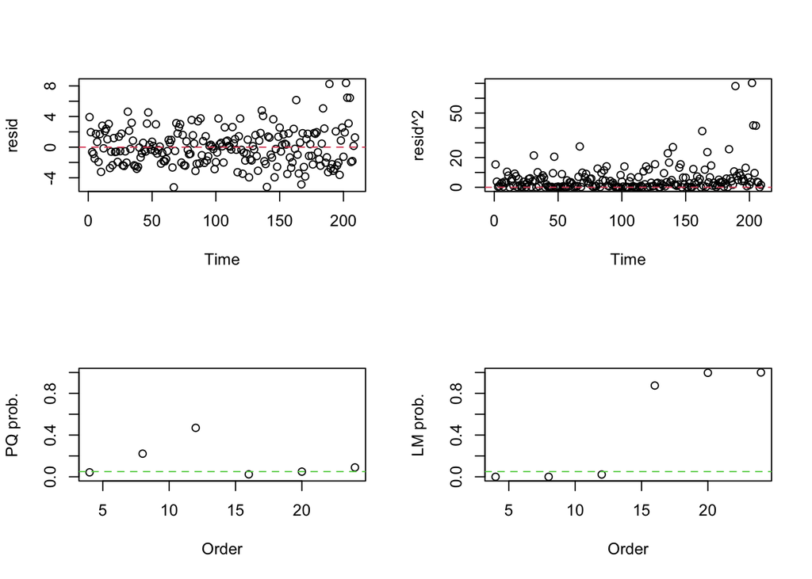

Тест Энгла не отвергает гипотезу о гомоскедестичности остатков на всех задержках, начиная с задержки в 16 недели. Заметим, что Q-тест Портманто не отвергает гипотезу о гомоскедестичности остатков, начиная с задержки в 24 недели. Соответственно, можно считать, что остатки в целом гомоскедестичны, и рассматривать GARCH модель не имеет смысла.

Построим предсказание с помощью сезонной ARMA модели на 12 недель вперед.

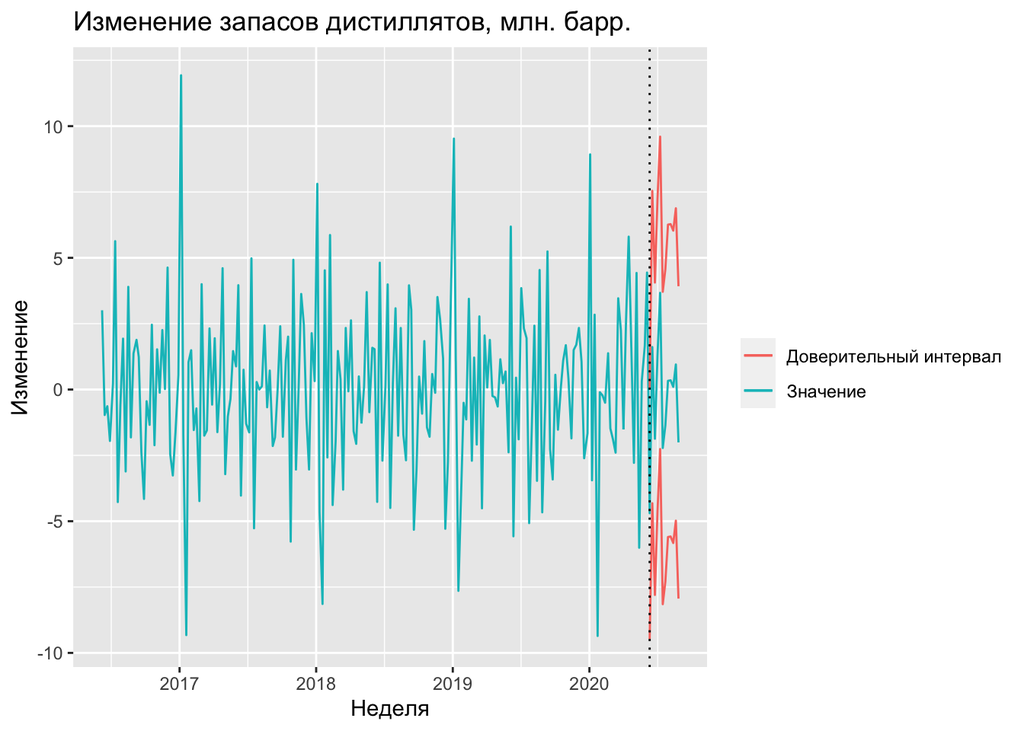

```r
fc <- predict(ma_model, n.ahead = 12)
fc_bottom <- fc$pred - 2 * fc$se
fc_up <- fc$pred + 2 * fc$se

forecast <- tibble(
  Date = seq(from=as.Date("2020/06/10"), by="week", length.out = length(fc$pred)),
  Diff = fc$pred,
  Bottom = fc_bottom,
  Up = fc_up
)

merged <- bind_rows(diff %>% select(Date, Diff, Inc), forecast) %>%
  arrange(Date) %>%
  mutate(Restored = Diff + lag(Inc, n = 52),
    Inc_Bottom = Bottom + lag(Inc, n = 52),
    Inc_Up = Up + lag(Inc, n = 52)) %>%
  mutate(Inc = coalesce(Inc, Restored)) %>%
  select(-Restored)

ggplot(merged) +
  geom_line(aes(x=Date, y = Inc, color="Значение")) +
  geom_line(aes(x=Date, y = Inc_Bottom, color="Доверительный интервал")) +
  geom_line(aes(x=Date, y = Inc_Up, color="Доверительный интервал")) +
  geom_vline(xintercept = as.Date("2020/06/10"), linetype="dotted") +
  labs(title='Изменение запасов дистиллятов, млн. барр.', x='Неделя', y='Изменение', color='')
```

### Оценка GARCH модели для тестового временного ряда

Считаем тестовый временной ряд и для удобства переименуем колонки. Заметим, что во временном ряде нет пропущенных значений.

```r
data %>% head()
```

```
## # A tibble: 6 x 2
##    Time Value
##   <int> <dbl>
## 1     1 -3.48
## 2     2 -5.63
## 3     3 -6.23
## 4     4 -2.04
## 5     5  2.05
## 6     6  6.50
```

```r
data %>% summary()
```

```
##       Time           Value
##  Min.   :  1.0   Min.   :-51.7264
##  1st Qu.:125.8   1st Qu.: -4.5658
##  Median :250.5   Median :  0.5259
##  Mean   :250.5   Mean   :  0.2727
##  3rd Qu.:375.2   3rd Qu.:  4.9450
##  Max.   :500.0   Max.   : 38.9758
```

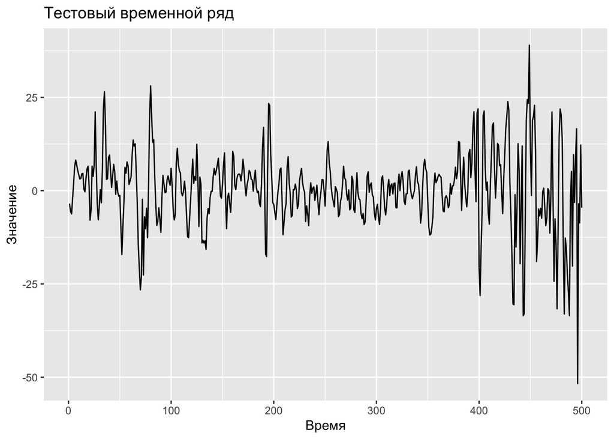

Рассмотрим ACF и PACF для исследуемого ряда.

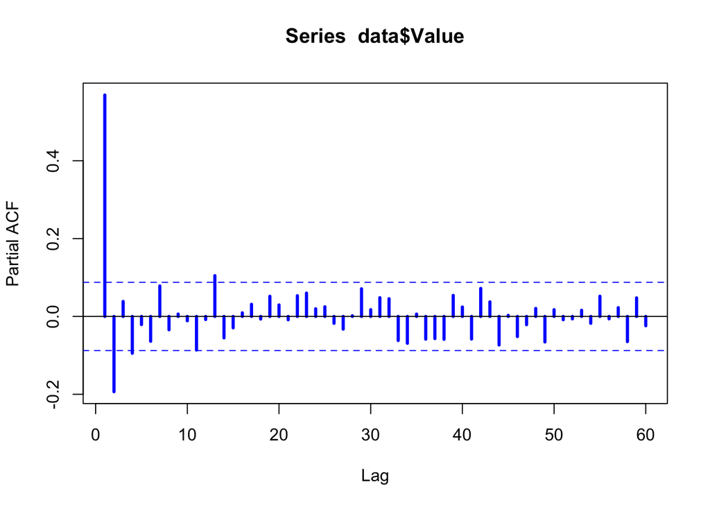

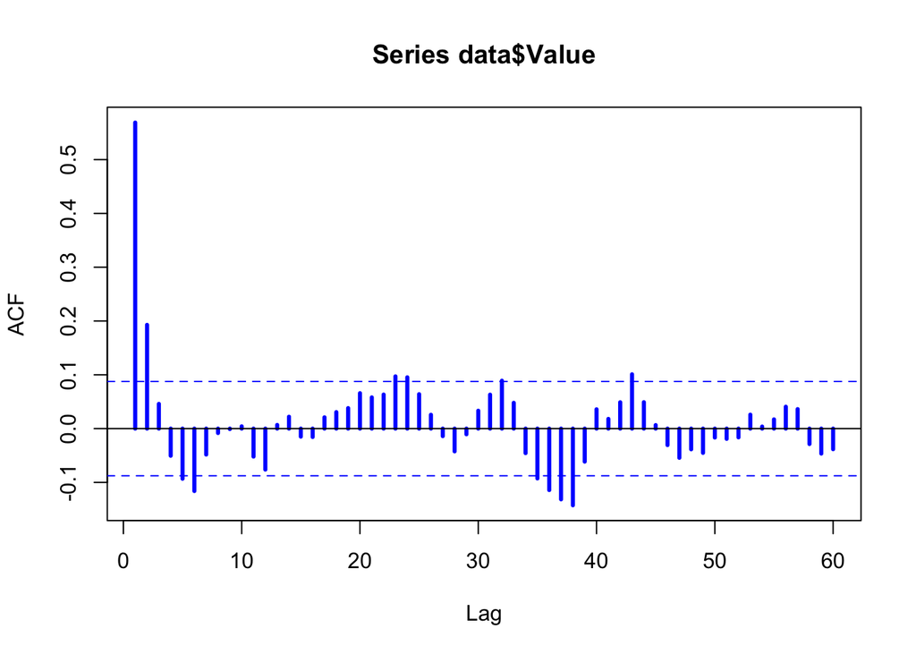

Согласно виду графика PACF, применим для описания временного ряда модель с авторегрессией 4 порядка.

```r
ar_model <- arima(data$Value, order = c(4,0,0),method = "ML")
coeftest(ar_model)
```

```
##
## z test of coefficients:
##
##            Estimate Std. Error z value  Pr(>|z|)
## ar1        0.692633   0.044605 15.5281 < 2.2e-16 ***
## ar2       -0.247471   0.054525 -4.5387  5.66e-06 ***
## ar3        0.111211   0.054640  2.0353   0.04182 *
## ar4       -0.097845   0.044755 -2.1862   0.02880 *
## intercept  0.254451   0.659617  0.3858   0.69968
## ---
## Signif. codes:  0 '***' 0.001 '**' 0.01 '*' 0.05 '.' 0.1 ' ' 1
```

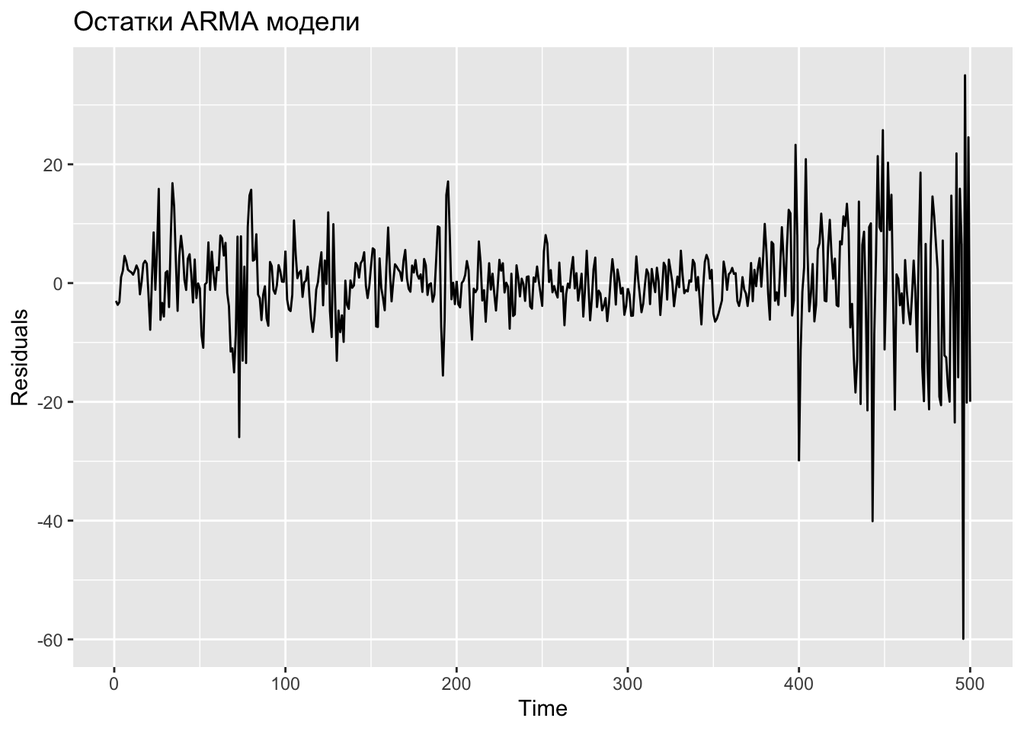

```r
arch.test(ar_model)
```

```
## ARCH heteroscedasticity test for residuals
## alternative: heteroscedastic
##
## Portmanteau-Q test:
##      order  PQ p.value
## [1,]     4 127       0
## [2,]     8 169       0
## [3,]    12 190       0
## [4,]    16 206       0
## [5,]    20 215       0
## [6,]    24 223       0
## Lagrange-Multiplier test:
##      order    LM  p.value
## [1,]     4 393.2 0.00e+00
## [2,]     8 149.0 0.00e+00
## [3,]    12  92.9 4.44e-15
## [4,]    16  58.6 4.39e-07
## [5,]    20  44.7 7.58e-04
## [6,]    24  34.5 5.81e-02
```

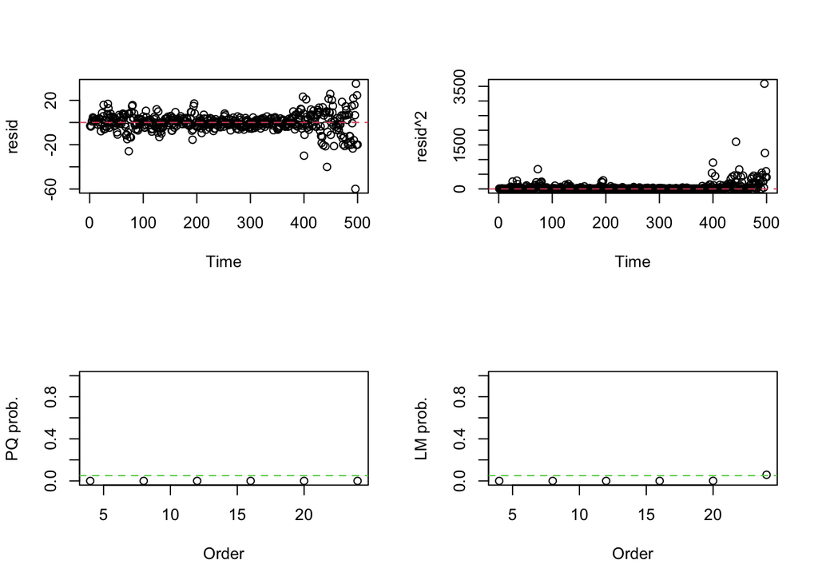

Заметим также, что остатки имеют ненормальное распределение.

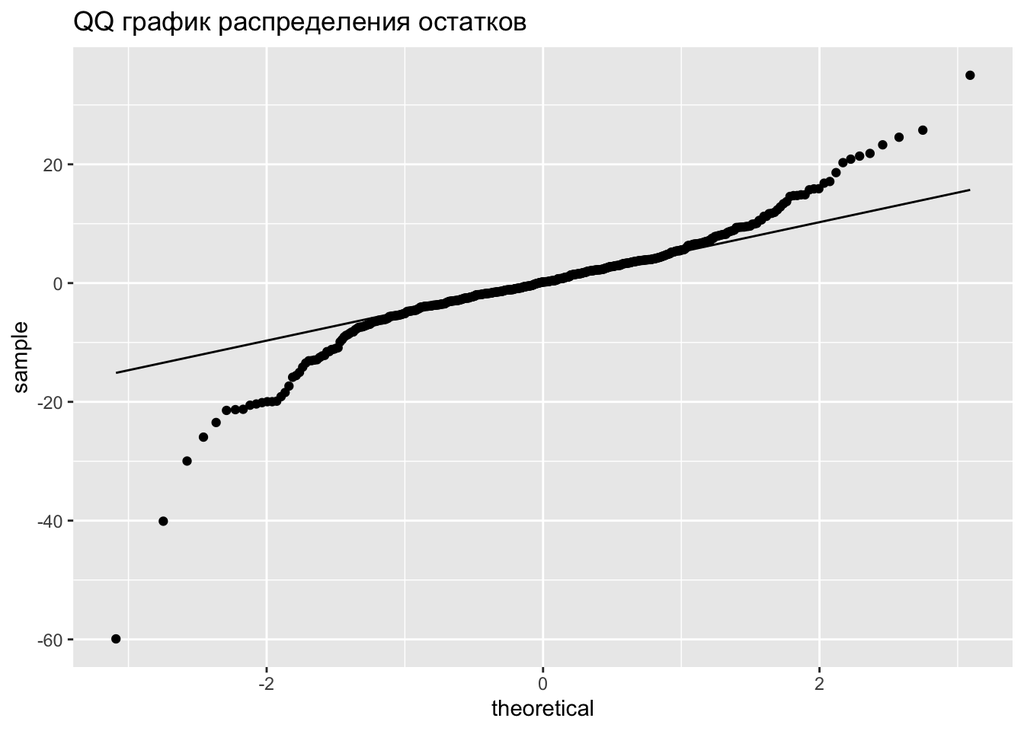

```r
ggplot(residuals, aes(sample=Residuals)) +
  geom_qq() +
  geom_qq_line() +
  labs(title='QQ график распределения остатков')
```

```r
estimate_model <- function(r, m, dist) {
  spec <- ugarchspec(variance.model = list(model="sGARCH", garchOrder = c(r,m)),
                     mean.model = list(armaOrder = c(4, 0)),
                     distribution.model = dist)
  fitarch <- ugarchfit(data$Value, spec = spec)
  fitarch
}

results <- crossing(
  tibble(r=0:3),
  tibble(m=1:3),
  tibble(dist=c('std', 'ged'))
) %>%
  rowwise() %>%
  summarise(r=r, m=m, dist=dist, aic=infocriteria(estimate_model(r, m, dist))[1]) %>%
  ungroup()
optimal <- results %>% top_n(1, -aic)
optimal
```

```
## # A tibble: 1 x 4
##       r     m dist    aic
##   <int> <int> <chr> <dbl>
## 1     2     1 ged    6.21
```

```r
optimal_model <- estimate_model(optimal$r[1], optimal$m[1], optimal$dist[1])
optimal_model
```

```
##
## *---------------------------------*
## *          GARCH Model Fit        *
## *---------------------------------*
##
## Conditional Variance Dynamics
## -----------------------------------
## GARCH Model  : sGARCH(2,1)
## Mean Model   : ARFIMA(4,0,0)
## Distribution : ged
##
## Optimal Parameters
## ------------------------------------
##         Estimate  Std. Error  t value Pr(>|t|)
## mu       0.69652    0.449339   1.5501 0.121120
## ar1      1.07468    0.045958  23.3837 0.000000
## ar2     -0.69342    0.066860 -10.3712 0.000000
## ar3      0.37387    0.065062   5.7463 0.000000
## ar4     -0.15023    0.043888  -3.4230 0.000619
## omega    2.23531    0.731773   3.0547 0.002253
## alpha1   0.22742    0.069902   3.2534 0.001141
## alpha2   0.23534    0.098458   2.3903 0.016835
## beta1    0.53624    0.070212   7.6375 0.000000
## shape    1.86923    0.188641   9.9089 0.000000
##
## Robust Standard Errors:
##         Estimate  Std. Error  t value Pr(>|t|)
## mu       0.69652    0.542620   1.2836 0.199276
## ar1      1.07468    0.048552  22.1348 0.000000
## ar2     -0.69342    0.068631 -10.1036 0.000000
## ar3      0.37387    0.061867   6.0431 0.000000
## ar4     -0.15023    0.045115  -3.3300 0.000869
## omega    2.23531    0.556221   4.0187 0.000059
## alpha1   0.22742    0.061467   3.6998 0.000216
## alpha2   0.23534    0.088378   2.6629 0.007747
## beta1    0.53624    0.059454   9.0194 0.000000
## shape    1.86923    0.176518  10.5894 0.000000
##
## LogLikelihood : -1542.479
##
```

[output cut: 55 more lines]

```
## Negative Sign Bias  0.1907 0.8489
## Positive Sign Bias  0.1675 0.8670
## Joint Effect        0.1275 0.9883
##
##
## Adjusted Pearson Goodness-of-Fit Test:
## ------------------------------------
##   group statistic p-value(g-1)
## 1    20     11.84       0.8923
## 2    30     12.76       0.9961
## 3    40     22.88       0.9814
## 4    50     36.80       0.9004
##
##
## Elapsed time : 1.112827
```

Построим с помощью полученной модели прогноз на 12 интервалов вперед с доверительным интервалом 0.95.

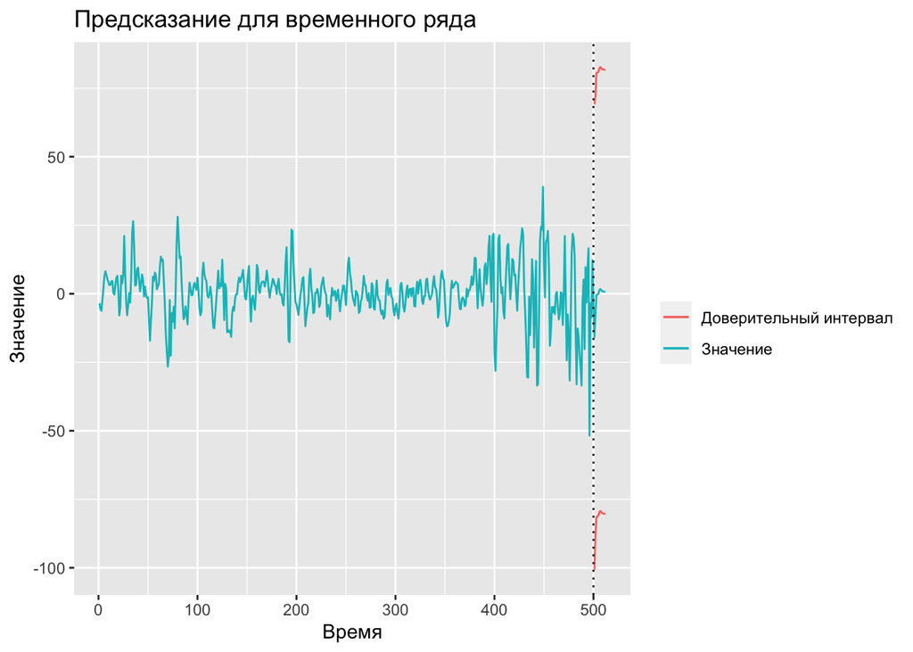

```r
fc <- ugarchforecast(optimal_model, n.ahead=12)
forecast <- tibble(
  Time = length(data$Value)+1:12,
  Value = fc@forecast$seriesFor,
  Bottom = fc@forecast$seriesFor - 2 * fc@forecast$sigmaFor,
  Up = fc@forecast$seriesFor + 2 * fc@forecast$sigmaFor
)

merged <- bind_rows(data %>% select(Time, Value), forecast) %>% arrange(Time)
ggplot(merged) +
  geom_line(aes(x=Time, y = Value, color="Значение")) +
  geom_line(aes(x=Time, y = Bottom, color="Доверительный интервал")) +
  geom_line(aes(x=Time, y = Up, color="Доверительный интервал")) +
  geom_vline(xintercept = length(data$Value), linetype="dotted") +
  labs(title='Предсказание для временного ряда', x='Время', y='Значение', color='')
```